# Risk Factor Analysis

## Outcome Variable

**Outcome Variable:** ever_swasted

## Predictor Variables

**Intervention Variable:** impsan

**Adjustment Set:**

unadjusted

## Stratifying Variables

The analysis was stratified on these variable(s):

- agecat
- studyid
- country

## Data Summary

| agecat | studyid | country | impsan | ever_swasted | n_cell | n |
| --- | --- | --- | --- | --- | --- | --- |
| 0-24 months (no birth wast) | ki0047075b-MAL-ED | BANGLADESH | 1 | 0 | 193 | 242 |
| 0-24 months (no birth wast) | ki0047075b-MAL-ED | BANGLADESH | 1 | 1 | 11 | 242 |
| 0-24 months (no birth wast) | ki0047075b-MAL-ED | BANGLADESH | 0 | 0 | 37 | 242 |
| 0-24 months (no birth wast) | ki0047075b-MAL-ED | BANGLADESH | 0 | 1 | 1 | 242 |
| 0-24 months (no birth wast) | ki0047075b-MAL-ED | BRAZIL | 1 | 0 | 202 | 209 |
| 0-24 months (no birth wast) | ki0047075b-MAL-ED | BRAZIL | 1 | 1 | 3 | 209 |
| 0-24 months (no birth wast) | ki0047075b-MAL-ED | BRAZIL | 0 | 0 | 4 | 209 |
| 0-24 months (no birth wast) | ki0047075b-MAL-ED | BRAZIL | 0 | 1 | 0 | 209 |
| 0-24 months (no birth wast) | ki0047075b-MAL-ED | INDIA | 1 | 0 | 103 | 229 |
| 0-24 months (no birth wast) | ki0047075b-MAL-ED | INDIA | 1 | 1 | 2 | 229 |
| 0-24 months (no birth wast) | ki0047075b-MAL-ED | INDIA | 0 | 0 | 116 | 229 |
| 0-24 months (no birth wast) | ki0047075b-MAL-ED | INDIA | 0 | 1 | 8 | 229 |
| 0-24 months (no birth wast) | ki0047075b-MAL-ED | NEPAL | 1 | 0 | 232 | 236 |
| 0-24 months (no birth wast) | ki0047075b-MAL-ED | NEPAL | 1 | 1 | 3 | 236 |
| 0-24 months (no birth wast) | ki0047075b-MAL-ED | NEPAL | 0 | 0 | 1 | 236 |
| 0-24 months (no birth wast) | ki0047075b-MAL-ED | NEPAL | 0 | 1 | 0 | 236 |
| 0-24 months (no birth wast) | ki0047075b-MAL-ED | PERU | 1 | 0 | 65 | 263 |
| 0-24 months (no birth wast) | ki0047075b-MAL-ED | PERU | 1 | 1 | 0 | 263 |
| 0-24 months (no birth wast) | ki0047075b-MAL-ED | PERU | 0 | 0 | 195 | 263 |
| 0-24 months (no birth wast) | ki0047075b-MAL-ED | PERU | 0 | 1 | 3 | 263 |
| 0-24 months (no birth wast) | ki0047075b-MAL-ED | SOUTH AFRICA | 1 | 0 | 4 | 250 |
| 0-24 months (no birth wast) | ki0047075b-MAL-ED | SOUTH AFRICA | 1 | 1 | 0 | 250 |
| 0-24 months (no birth wast) | ki0047075b-MAL-ED | SOUTH AFRICA | 0 | 0 | 235 | 250 |
| 0-24 months (no birth wast) | ki0047075b-MAL-ED | SOUTH AFRICA | 0 | 1 | 11 | 250 |
| 0-24 months (no birth wast) | ki0047075b-MAL-ED | TANZANIA, UNITED REPUBLIC OF | 1 | 0 | 0 | 241 |
| 0-24 months (no birth wast) | ki0047075b-MAL-ED | TANZANIA, UNITED REPUBLIC OF | 1 | 1 | 0 | 241 |
| 0-24 months (no birth wast) | ki0047075b-MAL-ED | TANZANIA, UNITED REPUBLIC OF | 0 | 0 | 235 | 241 |
| 0-24 months (no birth wast) | ki0047075b-MAL-ED | TANZANIA, UNITED REPUBLIC OF | 0 | 1 | 6 | 241 |
| 0-24 months (no birth wast) | ki1017093-NIH-Birth | BANGLADESH | 1 | 0 | 216 | 598 |
| 0-24 months (no birth wast) | ki1017093-NIH-Birth | BANGLADESH | 1 | 1 | 17 | 598 |

[output cut: 174 more lines]

The following strata were considered:

- agecat: 0-24 months (no birth wast), studyid: ki0047075b-MAL-ED, country: BANGLADESH
- agecat: 0-24 months (no birth wast), studyid: ki0047075b-MAL-ED, country: BRAZIL
- agecat: 0-24 months (no birth wast), studyid: ki0047075b-MAL-ED, country: INDIA
- agecat: 0-24 months (no birth wast), studyid: ki0047075b-MAL-ED, country: NEPAL
- agecat: 0-24 months (no birth wast), studyid: ki0047075b-MAL-ED, country: PERU
- agecat: 0-24 months (no birth wast), studyid: ki0047075b-MAL-ED, country: SOUTH AFRICA
- agecat: 0-24 months (no birth wast), studyid: ki0047075b-MAL-ED, country: TANZANIA, UNITED REPUBLIC OF
- agecat: 0-24 months (no birth wast), studyid: ki1017093-NIH-Birth, country: BANGLADESH
- agecat: 0-24 months (no birth wast), studyid: ki1017093b-PROVIDE, country: BANGLADESH
- agecat: 0-24 months (no birth wast), studyid: ki1017093c-NIH-Crypto, country: BANGLADESH
- agecat: 0-24 months (no birth wast), studyid: ki1114097-CONTENT, country: PERU
- agecat: 0-24 months (no birth wast), studyid: ki1135781-COHORTS, country: GUATEMALA
- agecat: 0-24 months (no birth wast), studyid: ki1135781-COHORTS, country: INDIA
- agecat: 0-24 months (no birth wast), studyid: ki1135781-COHORTS, country: PHILIPPINES
- agecat: 0-24 months (no birth wast), studyid: ki1148112-LCNI-5, country: MALAWI
- agecat: 0-24 months (no birth wast), studyid: kiGH5241-JiVitA-3, country: BANGLADESH
- agecat: 0-24 months (no birth wast), studyid: kiGH5241-JiVitA-4, country: BANGLADESH
- agecat: 0-6 months (no birth wast), studyid: ki0047075b-MAL-ED, country: BANGLADESH
- agecat: 0-6 months (no birth wast), studyid: ki0047075b-MAL-ED, country: BRAZIL
- agecat: 0-6 months (no birth wast), studyid: ki0047075b-MAL-ED, country: INDIA
- agecat: 0-6 months (no birth wast), studyid: ki0047075b-MAL-ED, country: NEPAL
- agecat: 0-6 months (no birth wast), studyid: ki0047075b-MAL-ED, country: PERU
- agecat: 0-6 months (no birth wast), studyid: ki0047075b-MAL-ED, country: SOUTH AFRICA
- agecat: 0-6 months (no birth wast), studyid: ki0047075b-MAL-ED, country: TANZANIA, UNITED REPUBLIC OF
- agecat: 0-6 months (no birth wast), studyid: ki1017093-NIH-Birth, country: BANGLADESH
- agecat: 0-6 months (no birth wast), studyid: ki1017093b-PROVIDE, country: BANGLADESH
- agecat: 0-6 months (no birth wast), studyid: ki1017093c-NIH-Crypto, country: BANGLADESH
- agecat: 0-6 months (no birth wast), studyid: ki1114097-CONTENT, country: PERU
- agecat: 0-6 months (no birth wast), studyid: ki1135781-COHORTS, country: GUATEMALA
- agecat: 0-6 months (no birth wast), studyid: ki1135781-COHORTS, country: INDIA
- agecat: 0-6 months (no birth wast), studyid: ki1135781-COHORTS, country: PHILIPPINES
- agecat: 0-6 months (no birth wast), studyid: ki1148112-LCNI-5, country: MALAWI
- agecat: 0-6 months (no birth wast), studyid: kiGH5241-JiVitA-3, country: BANGLADESH
- agecat: 0-6 months (no birth wast), studyid: kiGH5241-JiVitA-4, country: BANGLADESH
- agecat: 6-24 months, studyid: ki0047075b-MAL-ED, country: BANGLADESH
- agecat: 6-24 months, studyid: ki0047075b-MAL-ED, country: BRAZIL
- agecat: 6-24 months, studyid: ki0047075b-MAL-ED, country: INDIA
- agecat: 6-24 months, studyid: ki0047075b-MAL-ED, country: NEPAL
- agecat: 6-24 months, studyid: ki0047075b-MAL-ED, country: PERU
- agecat: 6-24 months, studyid: ki0047075b-MAL-ED, country: SOUTH AFRICA
- agecat: 6-24 months, studyid: ki0047075b-MAL-ED, country: TANZANIA, UNITED REPUBLIC OF
- agecat: 6-24 months, studyid: ki1017093-NIH-Birth, country: BANGLADESH
- agecat: 6-24 months, studyid: ki1017093b-PROVIDE, country: BANGLADESH
- agecat: 6-24 months, studyid: ki1017093c-NIH-Crypto, country: BANGLADESH
- agecat: 6-24 months, studyid: ki1114097-CONTENT, country: PERU
- agecat: 6-24 months, studyid: ki1135781-COHORTS, country: GUATEMALA
- agecat: 6-24 months, studyid: ki1135781-COHORTS, country: INDIA
- agecat: 6-24 months, studyid: ki1135781-COHORTS, country: PHILIPPINES
- agecat: 6-24 months, studyid: ki1148112-LCNI-5, country: MALAWI
- agecat: 6-24 months, studyid: kiGH5241-JiVitA-3, country: BANGLADESH
- agecat: 6-24 months, studyid: kiGH5241-JiVitA-4, country: BANGLADESH

### Dropped Strata

Some strata were dropped due to rare outcomes:

- agecat: 0-24 months (no birth wast), studyid: ki0047075b-MAL-ED, country: BANGLADESH
- agecat: 0-24 months (no birth wast), studyid: ki0047075b-MAL-ED, country: BRAZIL
- agecat: 0-24 months (no birth wast), studyid: ki0047075b-MAL-ED, country: INDIA
- agecat: 0-24 months (no birth wast), studyid: ki0047075b-MAL-ED, country: NEPAL
- agecat: 0-24 months (no birth wast), studyid: ki0047075b-MAL-ED, country: PERU
- agecat: 0-24 months (no birth wast), studyid: ki0047075b-MAL-ED, country: SOUTH AFRICA
- agecat: 0-24 months (no birth wast), studyid: ki0047075b-MAL-ED, country: TANZANIA, UNITED REPUBLIC OF
- agecat: 0-24 months (no birth wast), studyid: ki1017093b-PROVIDE, country: BANGLADESH
- agecat: 0-24 months (no birth wast), studyid: ki1017093c-NIH-Crypto, country: BANGLADESH
- agecat: 0-24 months (no birth wast), studyid: ki1114097-CONTENT, country: PERU
- agecat: 0-24 months (no birth wast), studyid: ki1135781-COHORTS, country: GUATEMALA
- agecat: 0-24 months (no birth wast), studyid: ki1148112-LCNI-5, country: MALAWI
- agecat: 0-6 months (no birth wast), studyid: ki0047075b-MAL-ED, country: BANGLADESH
- agecat: 0-6 months (no birth wast), studyid: ki0047075b-MAL-ED, country: BRAZIL
- agecat: 0-6 months (no birth wast), studyid: ki0047075b-MAL-ED, country: INDIA
- agecat: 0-6 months (no birth wast), studyid: ki0047075b-MAL-ED, country: NEPAL
- agecat: 0-6 months (no birth wast), studyid: ki0047075b-MAL-ED, country: PERU
- agecat: 0-6 months (no birth wast), studyid: ki0047075b-MAL-ED, country: SOUTH AFRICA
- agecat: 0-6 months (no birth wast), studyid: ki0047075b-MAL-ED, country: TANZANIA, UNITED REPUBLIC OF
- agecat: 0-6 months (no birth wast), studyid: ki1017093-NIH-Birth, country: BANGLADESH
- agecat: 0-6 months (no birth wast), studyid: ki1017093b-PROVIDE, country: BANGLADESH
- agecat: 0-6 months (no birth wast), studyid: ki1017093c-NIH-Crypto, country: BANGLADESH
- agecat: 0-6 months (no birth wast), studyid: ki1114097-CONTENT, country: PERU
- agecat: 0-6 months (no birth wast), studyid: ki1135781-COHORTS, country: GUATEMALA
- agecat: 0-6 months (no birth wast), studyid: ki1135781-COHORTS, country: PHILIPPINES
- agecat: 0-6 months (no birth wast), studyid: ki1148112-LCNI-5, country: MALAWI
- agecat: 0-6 months (no birth wast), studyid: kiGH5241-JiVitA-4, country: BANGLADESH
- agecat: 6-24 months, studyid: ki0047075b-MAL-ED, country: BANGLADESH
- agecat: 6-24 months, studyid: ki0047075b-MAL-ED, country: BRAZIL
- agecat: 6-24 months, studyid: ki0047075b-MAL-ED, country: INDIA
- agecat: 6-24 months, studyid: ki0047075b-MAL-ED, country: NEPAL
- agecat: 6-24 months, studyid: ki0047075b-MAL-ED, country: PERU
- agecat: 6-24 months, studyid: ki0047075b-MAL-ED, country: SOUTH AFRICA
- agecat: 6-24 months, studyid: ki0047075b-MAL-ED, country: TANZANIA, UNITED REPUBLIC OF
- agecat: 6-24 months, studyid: ki1017093b-PROVIDE, country: BANGLADESH
- agecat: 6-24 months, studyid: ki1017093c-NIH-Crypto, country: BANGLADESH
- agecat: 6-24 months, studyid: ki1114097-CONTENT, country: PERU
- agecat: 6-24 months, studyid: ki1135781-COHORTS, country: GUATEMALA
- agecat: 6-24 months, studyid: ki1148112-LCNI-5, country: MALAWI

## Methods Detail

We’re interested in the causal parameters $E[Y_a]$ for all values of $a \in \mathcal{A}$. These parameters represent the mean outcome if, possibly contrary to fact, we intervened to set all units to have $A=a$. Under the randomization and positivity assumptions, these are identified by the statistical parameters $\psi_a=E_W[E_{Y|A,W}(Y|A=a,W)]$. In addition, we’re interested in the mean of $Y$, $E[Y]$ under no intervention (the observed mean). We will estimate these parameters by using SuperLearner to fit the relevant likelihood factors – $E_{Y|A,W}(Y|A=a,W)$ and $p(A=a|W)$, and then updating our likelihood fit using a joint TMLE.

For unadjusted analyses ($W=\{\}$), initial likelihoods were estimated using Lrnr_glm to estimate the simple $E(Y|A)$ and Lrnr_mean to estimate $p(A)$. For adjusted analyses, a small library containing Lrnr_glmnet, Lrnr_xgboost, and Lrnr_mean was used.

Having estimated these parameters, we will then use the delta method to estimate relative risks and attributable risks relative to a prespecified baseline level of $A$.

# Results Detail

## Results Plots

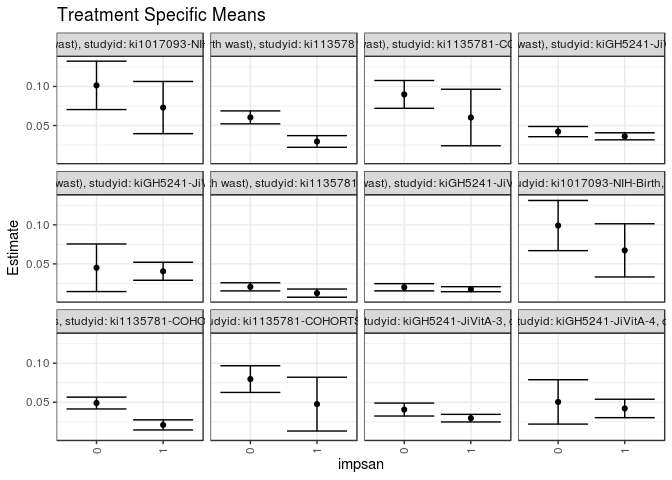

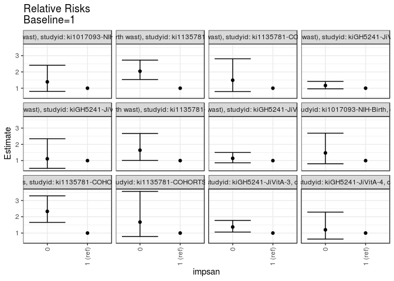

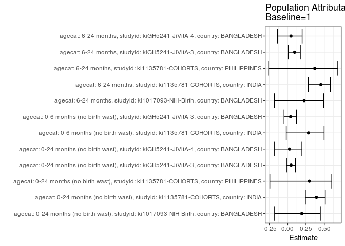

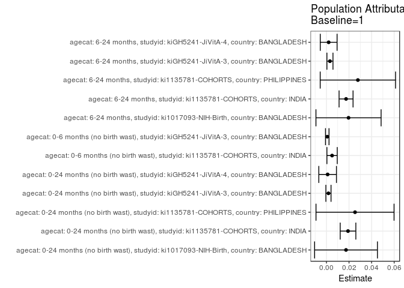

## Results Table

### Parameter: TSM

| agecat | studyid | country | intervention_level | baseline_level | estimate | ci_lower | ci_upper |
| --- | --- | --- | --- | --- | --- | --- | --- |
| 0-24 months (no birth wast) | ki1017093-NIH-Birth | BANGLADESH | 1 | NA | 0.0729614 | 0.0395396 | 0.1063831 |
| 0-24 months (no birth wast) | ki1017093-NIH-Birth | BANGLADESH | 0 | NA | 0.1013699 | 0.0703807 | 0.1323590 |
| 0-24 months (no birth wast) | ki1135781-COHORTS | INDIA | 1 | NA | 0.0295617 | 0.0220664 | 0.0370570 |
| 0-24 months (no birth wast) | ki1135781-COHORTS | INDIA | 0 | NA | 0.0604258 | 0.0521616 | 0.0686900 |
| 0-24 months (no birth wast) | ki1135781-COHORTS | PHILIPPINES | 1 | NA | 0.0602410 | 0.0240303 | 0.0964516 |
| 0-24 months (no birth wast) | ki1135781-COHORTS | PHILIPPINES | 0 | NA | 0.0898083 | 0.0719999 | 0.1076166 |
| 0-24 months (no birth wast) | kiGH5241-JiVitA-3 | BANGLADESH | 1 | NA | 0.0361512 | 0.0316317 | 0.0406706 |
| 0-24 months (no birth wast) | kiGH5241-JiVitA-3 | BANGLADESH | 0 | NA | 0.0421765 | 0.0356512 | 0.0487018 |
| 0-24 months (no birth wast) | kiGH5241-JiVitA-4 | BANGLADESH | 1 | NA | 0.0405530 | 0.0290356 | 0.0520704 |
| 0-24 months (no birth wast) | kiGH5241-JiVitA-4 | BANGLADESH | 0 | NA | 0.0450450 | 0.0145740 | 0.0755161 |
| 0-6 months (no birth wast) | ki1135781-COHORTS | INDIA | 1 | NA | 0.0125714 | 0.0073508 | 0.0177920 |
| 0-6 months (no birth wast) | ki1135781-COHORTS | INDIA | 0 | NA | 0.0206294 | 0.0154195 | 0.0258393 |
| 0-6 months (no birth wast) | kiGH5241-JiVitA-3 | BANGLADESH | 1 | NA | 0.0175982 | 0.0144080 | 0.0207885 |
| 0-6 months (no birth wast) | kiGH5241-JiVitA-3 | BANGLADESH | 0 | NA | 0.0200634 | 0.0154464 | 0.0246803 |
| 6-24 months | ki1017093-NIH-Birth | BANGLADESH | 1 | NA | 0.0673077 | 0.0332261 | 0.1013893 |
| 6-24 months | ki1017093-NIH-Birth | BANGLADESH | 0 | NA | 0.0990991 | 0.0669772 | 0.1312210 |
| 6-24 months | ki1135781-COHORTS | INDIA | 1 | NA | 0.0210194 | 0.0145738 | 0.0274651 |
| 6-24 months | ki1135781-COHORTS | INDIA | 0 | NA | 0.0490070 | 0.0414336 | 0.0565805 |
| 6-24 months | ki1135781-COHORTS | PHILIPPINES | 1 | NA | 0.0476190 | 0.0131777 | 0.0820604 |
| 6-24 months | ki1135781-COHORTS | PHILIPPINES | 0 | NA | 0.0797101 | 0.0626228 | 0.0967975 |
| 6-24 months | kiGH5241-JiVitA-3 | BANGLADESH | 1 | NA | 0.0296514 | 0.0247594 | 0.0345433 |
| 6-24 months | kiGH5241-JiVitA-3 | BANGLADESH | 0 | NA | 0.0406639 | 0.0323969 | 0.0489309 |
| 6-24 months | kiGH5241-JiVitA-4 | BANGLADESH | 1 | NA | 0.0420860 | 0.0303034 | 0.0538686 |
| 6-24 months | kiGH5241-JiVitA-4 | BANGLADESH | 0 | NA | 0.0504451 | 0.0220293 | 0.0788609 |

### Parameter: E(Y)

| agecat | studyid | country | intervention_level | baseline_level | estimate | ci_lower | ci_upper |
| --- | --- | --- | --- | --- | --- | --- | --- |
| 0-24 months (no birth wast) | ki1017093-NIH-Birth | BANGLADESH | NA | NA | 0.0903010 | 0.0673101 | 0.1132919 |
| 0-24 months (no birth wast) | ki1135781-COHORTS | INDIA | NA | NA | 0.0486811 | 0.0428066 | 0.0545557 |
| 0-24 months (no birth wast) | ki1135781-COHORTS | PHILIPPINES | NA | NA | 0.0855661 | 0.0694412 | 0.1016910 |
| 0-24 months (no birth wast) | kiGH5241-JiVitA-3 | BANGLADESH | NA | NA | 0.0379318 | 0.0341156 | 0.0417480 |
| 0-24 months (no birth wast) | kiGH5241-JiVitA-4 | BANGLADESH | NA | NA | 0.0416079 | 0.0305327 | 0.0526831 |
| 0-6 months (no birth wast) | ki1135781-COHORTS | INDIA | NA | NA | 0.0175705 | 0.0137775 | 0.0213635 |
| 0-6 months (no birth wast) | kiGH5241-JiVitA-3 | BANGLADESH | NA | NA | 0.0183264 | 0.0155587 | 0.0210942 |
| 6-24 months | ki1017093-NIH-Birth | BANGLADESH | NA | NA | 0.0868762 | 0.0631205 | 0.1106318 |
| 6-24 months | ki1135781-COHORTS | INDIA | NA | NA | 0.0384080 | 0.0330939 | 0.0437221 |
| 6-24 months | ki1135781-COHORTS | PHILIPPINES | NA | NA | 0.0754717 | 0.0599461 | 0.0909973 |
| 6-24 months | kiGH5241-JiVitA-3 | BANGLADESH | NA | NA | 0.0327562 | 0.0284806 | 0.0370318 |
| 6-24 months | kiGH5241-JiVitA-4 | BANGLADESH | NA | NA | 0.0440559 | 0.0331293 | 0.0549826 |

### Parameter: RR

| agecat | studyid | country | intervention_level | baseline_level | estimate | ci_lower | ci_upper |
| --- | --- | --- | --- | --- | --- | --- | --- |
| 0-24 months (no birth wast) | ki1017093-NIH-Birth | BANGLADESH | 1 | 1 | 1.000000 | 1.0000000 | 1.000000 |
| 0-24 months (no birth wast) | ki1017093-NIH-Birth | BANGLADESH | 0 | 1 | 1.389363 | 0.8010200 | 2.409841 |
| 0-24 months (no birth wast) | ki1135781-COHORTS | INDIA | 1 | 1 | 1.000000 | 1.0000000 | 1.000000 |
| 0-24 months (no birth wast) | ki1135781-COHORTS | INDIA | 0 | 1 | 2.044059 | 1.5324307 | 2.726503 |
| 0-24 months (no birth wast) | ki1135781-COHORTS | PHILIPPINES | 1 | 1 | 1.000000 | 1.0000000 | 1.000000 |
| 0-24 months (no birth wast) | ki1135781-COHORTS | PHILIPPINES | 0 | 1 | 1.490817 | 0.7916512 | 2.807469 |
| 0-24 months (no birth wast) | kiGH5241-JiVitA-3 | BANGLADESH | 1 | 1 | 1.000000 | 1.0000000 | 1.000000 |
| 0-24 months (no birth wast) | kiGH5241-JiVitA-3 | BANGLADESH | 0 | 1 | 1.166671 | 0.9619390 | 1.414977 |
| 0-24 months (no birth wast) | kiGH5241-JiVitA-4 | BANGLADESH | 1 | 1 | 1.000000 | 1.0000000 | 1.000000 |
| 0-24 months (no birth wast) | kiGH5241-JiVitA-4 | BANGLADESH | 0 | 1 | 1.110770 | 0.5261596 | 2.344934 |
| 0-6 months (no birth wast) | ki1135781-COHORTS | INDIA | 1 | 1 | 1.000000 | 1.0000000 | 1.000000 |
| 0-6 months (no birth wast) | ki1135781-COHORTS | INDIA | 0 | 1 | 1.640973 | 1.0092928 | 2.667998 |
| 0-6 months (no birth wast) | kiGH5241-JiVitA-3 | BANGLADESH | 1 | 1 | 1.000000 | 1.0000000 | 1.000000 |
| 0-6 months (no birth wast) | kiGH5241-JiVitA-3 | BANGLADESH | 0 | 1 | 1.140078 | 0.8660736 | 1.500771 |
| 6-24 months | ki1017093-NIH-Birth | BANGLADESH | 1 | 1 | 1.000000 | 1.0000000 | 1.000000 |
| 6-24 months | ki1017093-NIH-Birth | BANGLADESH | 0 | 1 | 1.472330 | 0.8070491 | 2.686025 |
| 6-24 months | ki1135781-COHORTS | INDIA | 1 | 1 | 1.000000 | 1.0000000 | 1.000000 |
| 6-24 months | ki1135781-COHORTS | INDIA | 0 | 1 | 2.331510 | 1.6538794 | 3.286781 |
| 6-24 months | ki1135781-COHORTS | PHILIPPINES | 1 | 1 | 1.000000 | 1.0000000 | 1.000000 |
| 6-24 months | ki1135781-COHORTS | PHILIPPINES | 0 | 1 | 1.673913 | 0.7872542 | 3.559187 |
| 6-24 months | kiGH5241-JiVitA-3 | BANGLADESH | 1 | 1 | 1.000000 | 1.0000000 | 1.000000 |
| 6-24 months | kiGH5241-JiVitA-3 | BANGLADESH | 0 | 1 | 1.371401 | 1.0595029 | 1.775117 |
| 6-24 months | kiGH5241-JiVitA-4 | BANGLADESH | 1 | 1 | 1.000000 | 1.0000000 | 1.000000 |
| 6-24 months | kiGH5241-JiVitA-4 | BANGLADESH | 0 | 1 | 1.198619 | 0.6288309 | 2.284698 |

### Parameter: PAR

| agecat | studyid | country | intervention_level | baseline_level | estimate | ci_lower | ci_upper |
| --- | --- | --- | --- | --- | --- | --- | --- |
| 0-24 months (no birth wast) | ki1017093-NIH-Birth | BANGLADESH | 1 | NA | 0.0173396 | -0.0105018 | 0.0451811 |
| 0-24 months (no birth wast) | ki1135781-COHORTS | INDIA | 1 | NA | 0.0191195 | 0.0121960 | 0.0260430 |
| 0-24 months (no birth wast) | ki1135781-COHORTS | PHILIPPINES | 1 | NA | 0.0253252 | -0.0092432 | 0.0598935 |
| 0-24 months (no birth wast) | kiGH5241-JiVitA-3 | BANGLADESH | 1 | NA | 0.0017807 | -0.0005028 | 0.0040642 |
| 0-24 months (no birth wast) | kiGH5241-JiVitA-4 | BANGLADESH | 1 | NA | 0.0010549 | -0.0067456 | 0.0088554 |
| 0-6 months (no birth wast) | ki1135781-COHORTS | INDIA | 1 | NA | 0.0049991 | 0.0004220 | 0.0095761 |
| 0-6 months (no birth wast) | kiGH5241-JiVitA-3 | BANGLADESH | 1 | NA | 0.0007282 | -0.0008315 | 0.0022879 |
| 6-24 months | ki1017093-NIH-Birth | BANGLADESH | 1 | NA | 0.0195685 | -0.0092883 | 0.0484252 |
| 6-24 months | ki1135781-COHORTS | INDIA | 1 | NA | 0.0173885 | 0.0111983 | 0.0235787 |
| 6-24 months | ki1135781-COHORTS | PHILIPPINES | 1 | NA | 0.0278526 | -0.0055227 | 0.0612280 |
| 6-24 months | kiGH5241-JiVitA-3 | BANGLADESH | 1 | NA | 0.0031048 | 0.0004208 | 0.0057889 |
| 6-24 months | kiGH5241-JiVitA-4 | BANGLADESH | 1 | NA | 0.0019699 | -0.0054749 | 0.0094148 |

### Parameter: PAF

| agecat | studyid | country | intervention_level | baseline_level | estimate | ci_lower | ci_upper |
| --- | --- | --- | --- | --- | --- | --- | --- |
| 0-24 months (no birth wast) | ki1017093-NIH-Birth | BANGLADESH | 1 | NA | 0.1920203 | -0.1785961 | 0.4460943 |
| 0-24 months (no birth wast) | ki1135781-COHORTS | INDIA | 1 | NA | 0.3927491 | 0.2420519 | 0.5134843 |
| 0-24 months (no birth wast) | ki1135781-COHORTS | PHILIPPINES | 1 | NA | 0.2959718 | -0.2437483 | 0.6014823 |
| 0-24 months (no birth wast) | kiGH5241-JiVitA-3 | BANGLADESH | 1 | NA | 0.0469440 | -0.0155815 | 0.1056201 |
| 0-24 months (no birth wast) | kiGH5241-JiVitA-4 | BANGLADESH | 1 | NA | 0.0253534 | -0.1790977 | 0.1943535 |
| 0-6 months (no birth wast) | ki1135781-COHORTS | INDIA | 1 | NA | 0.2845150 | -0.0194796 | 0.4978626 |
| 0-6 months (no birth wast) | kiGH5241-JiVitA-3 | BANGLADESH | 1 | NA | 0.0397358 | -0.0495524 | 0.1214280 |
| 6-24 months | ki1017093-NIH-Birth | BANGLADESH | 1 | NA | 0.2252455 | -0.1819773 | 0.4921691 |
| 6-24 months | ki1135781-COHORTS | INDIA | 1 | NA | 0.4527321 | 0.2813770 | 0.5832277 |
| 6-24 months | ki1135781-COHORTS | PHILIPPINES | 1 | NA | 0.3690476 | -0.2598982 | 0.6840214 |
| 6-24 months | kiGH5241-JiVitA-3 | BANGLADESH | 1 | NA | 0.0947866 | 0.0089185 | 0.1732150 |
| 6-24 months | kiGH5241-JiVitA-4 | BANGLADESH | 1 | NA | 0.0447146 | -0.1376326 | 0.1978340 |